# Homework3_FBDA

109090035_陳佑祥

3/13/2023

### Copy the dataset ‘diamonds’ from the ‘tidyverse’ package to ‘dmd’. Do the routine inquiry on ‘dmd’ using ‘head()’, ‘str()’, ‘skim()’.

```r
library(tidyverse)
dmd <- diamonds
#Use the head() function to view the first few rows of the dmd dataset
head(dmd)
```

```
## # A tibble: 6 × 10
##   carat cut       color clarity depth table price     x     y     z
##   <dbl> <ord>     <ord> <ord>   <dbl> <dbl> <int> <dbl> <dbl> <dbl>
## 1  0.23 Ideal     E     SI2      61.5    55   326  3.95  3.98  2.43
## 2  0.21 Premium   E     SI1      59.8    61   326  3.89  3.84  2.31
## 3  0.23 Good      E     VS1      56.9    65   327  4.05  4.07  2.31
## 4  0.29 Premium   I     VS2      62.4    58   334  4.2   4.23  2.63
## 5  0.31 Good      J     SI2      63.3    58   335  4.34  4.35  2.75
## 6  0.24 Very Good J     VVS2     62.8    57   336  3.94  3.96  2.48
```

```r
#Use the str() function to view the structure of the dmd dataset
str(dmd)
```

```
## tibble [53,940 × 10] (S3: tbl_df/tbl/data.frame)
##  $ carat  : num [1:53940] 0.23 0.21 0.23 0.29 0.31 0.24 0.24 0.26 0.22 0.23 ...
##  $ cut    : Ord.factor w/ 5 levels "Fair"<"Good"<..: 5 4 2 4 2 3 3 3 1 3 ...
##  $ color  : Ord.factor w/ 7 levels "D"<"E"<"F"<"G"<..: 2 2 2 6 7 7 6 5 2 5 ...
##  $ clarity: Ord.factor w/ 8 levels "I1"<"SI2"<"SI1"<..: 2 3 5 4 2 6 7 3 4 5 ...
##  $ depth  : num [1:53940] 61.5 59.8 56.9 62.4 63.3 62.8 62.3 61.9 65.1 59.4 ...
##  $ table  : num [1:53940] 55 61 65 58 58 57 57 55 61 61 ...
##  $ price  : int [1:53940] 326 326 327 334 335 336 336 337 337 338 ...
##  $ x      : num [1:53940] 3.95 3.89 4.05 4.2 4.34 3.94 3.95 4.07 3.87 4 ...
##  $ y      : num [1:53940] 3.98 3.84 4.07 4.23 4.35 3.96 3.98 4.11 3.78 4.05 ...
##  $ z      : num [1:53940] 2.43 2.31 2.31 2.63 2.75 2.48 2.47 2.53 2.49 2.39 ...
```

```r
#Use the skim() function from the skimr package to view a summary of the dmd dataset
library(skimr)
skim(dmd)
```

Data summary

| Name | dmd |
| --- | --- |
| Number of rows | 53940 |
| Number of columns | 10 |
| _______________________ |  |
| Column type frequency: |  |
| factor | 3 |
| numeric | 7 |
| ________________________ |  |
| Group variables | None |

**Variable type: factor**

| skim_variable | n_missing | complete_rate | ordered | n_unique | top_counts |
| --- | --- | --- | --- | --- | --- |
| cut | 0 | 1 | TRUE | 5 | Ide: 21551, Pre: 13791, Ver: 12082, Goo: 4906 |
| color | 0 | 1 | TRUE | 7 | G: 11292, E: 9797, F: 9542, H: 8304 |
| clarity | 0 | 1 | TRUE | 8 | SI1: 13065, VS2: 12258, SI2: 9194, VS1: 8171 |

**Variable type: numeric**

| skim_variable | n_missing | complete_rate | mean | sd | p0 | p25 | p50 | p75 | p100 | hist |
| --- | --- | --- | --- | --- | --- | --- | --- | --- | --- | --- |
| carat | 0 | 1 | 0.80 | 0.47 | 0.2 | 0.40 | 0.70 | 1.04 | 5.01 | ▇▂▁▁▁ |
| depth | 0 | 1 | 61.75 | 1.43 | 43.0 | 61.00 | 61.80 | 62.50 | 79.00 | ▁▁▇▁▁ |
| table | 0 | 1 | 57.46 | 2.23 | 43.0 | 56.00 | 57.00 | 59.00 | 95.00 | ▁▇▁▁▁ |
| price | 0 | 1 | 3932.80 | 3989.44 | 326.0 | 950.00 | 2401.00 | 5324.25 | 18823.00 | ▇▂▁▁▁ |
| x | 0 | 1 | 5.73 | 1.12 | 0.0 | 4.71 | 5.70 | 6.54 | 10.74 | ▁▁▇▃▁ |
| y | 0 | 1 | 5.73 | 1.14 | 0.0 | 4.72 | 5.71 | 6.54 | 58.90 | ▇▁▁▁▁ |
| z | 0 | 1 | 3.54 | 0.71 | 0.0 | 2.91 | 3.53 | 4.04 | 31.80 | ▇▁▁▁▁ |

### 1. Use the ‘skim()’ to see how different the mean and the median of the variable ‘price’ are. Please explain why they are so different

```r
skim(dmd$price)
```

Data summary

| Name | dmd$price |
| --- | --- |
| Number of rows | 53940 |
| Number of columns | 1 |
| _______________________ |  |
| Column type frequency: |  |
| numeric | 1 |
| ________________________ |  |
| Group variables | None |

**Variable type: numeric**

| skim_variable | n_missing | complete_rate | mean | sd | p0 | p25 | p50 | p75 | p100 | hist |
| --- | --- | --- | --- | --- | --- | --- | --- | --- | --- | --- |
| data | 0 | 1 | 3932.8 | 3989.44 | 326 | 950 | 2401 | 5324.25 | 18823 | ▇▂▁▁▁ |

The reason why the mean and median are so different in this case is because the price variable has a long tail of very high values, which is common in many datasets. The mean is more sensitive to outliers and extreme values than the median, so if a few very high values are present, they can have a disproportionate effect on the mean, causing it to be higher than the median. In this case, we can see from the summary that the maximum value of the price variable is 18823, which is much higher than the median value of 2401. This indicates that there are some very expensive diamonds in the dataset that are driving up the mean price.

### 2. Use the ‘boxplot()’ function to draw a box plot horizontally and explain how the resulting plot confirms your answer in the previous question.

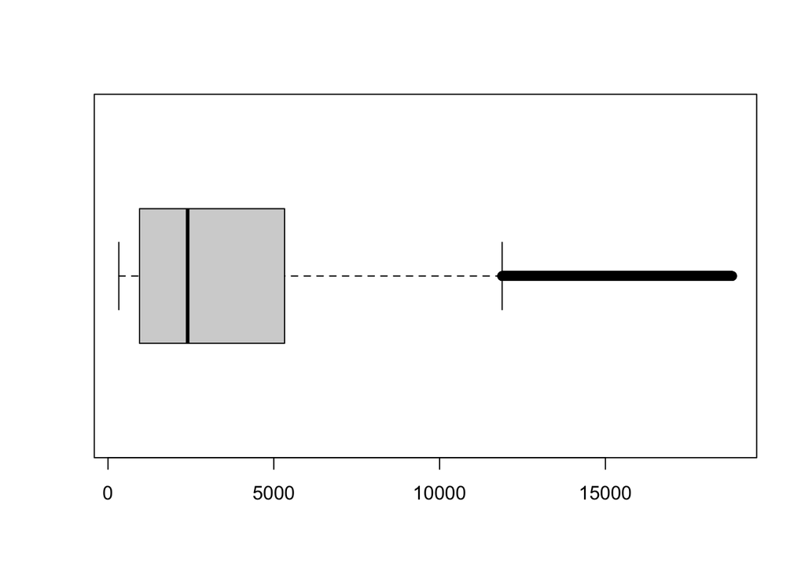

```r
boxplot(dmd$price, horizontal = TRUE)
```

The resulting plot confirms the answer to the previous question by showing that the distribution of the price variable is right-skewed, with a long tail of very high values. The box plot shows that the median (Q2) is located near the lower end of the interquartile range (IQR), which confirms that the median is lower than the mean.

### 3. Use the ‘hist()’, ‘density()’ and ‘lines()’ functions to overlap a histogram and a density plots. Please once again explain how the resulting plots confirm your answers in the previous questions. Please add the option ‘ylim = c(0,0.0004)’ to ‘hist()’ and explain what this option does.

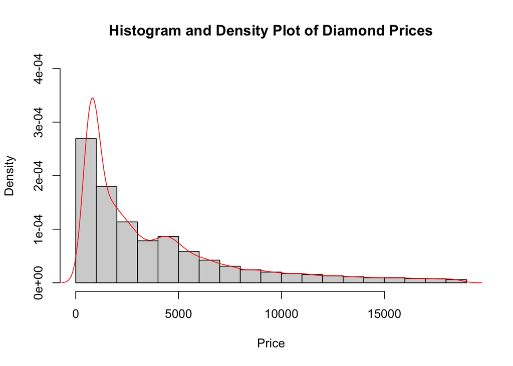

```r
hist(dmd$price, freq = FALSE, main = "Histogram and Density Plot of Diamond Prices", xlab = "Price", ylab = "Density", ylim = c(0,0.0004))

density <- density(dmd$price)
lines(density(dmd$price), col = "red")
```

The ylim = c(0,0.0004) option sets the y-axis limits of the histogram to be between 0 and 0.0004. This option can be useful when comparing histograms with different ranges of values, as it ensures that the y-axis is consistent across all plots.

The density plot also provides a visual representation of the shape of the distribution, which is useful for understanding the nature of the data. In this case, the density plot confirms that the distribution is right-skewed, as there is a long tail to the right of the peak.

### 4. Please extract observations with the smallest 40% values of the variable ‘price’ using the ‘subset()’ and ‘quantile()’ functions (add the option ‘probs = 0.4’ in the latter) and copy this subsample to ‘dmd’. We will work on this subsample ‘dmd’ only from now on. Please explain the possible reason why we want to delete so many observations.

```r
# Calculate the 40th percentile of the price variable
price_quantile <- quantile(diamonds$price, probs = 0.4)

# Subset the diamonds dataset to only include observations with price less than or equal to the 40th percentile
dmd <- subset(diamonds, price <= price_quantile)

# Print the first few rows of the new dataset
head(dmd)
```

```
## # A tibble: 6 × 10
##   carat cut       color clarity depth table price     x     y     z
##   <dbl> <ord>     <ord> <ord>   <dbl> <dbl> <int> <dbl> <dbl> <dbl>
## 1  0.23 Ideal     E     SI2      61.5    55   326  3.95  3.98  2.43
## 2  0.21 Premium   E     SI1      59.8    61   326  3.89  3.84  2.31
## 3  0.23 Good      E     VS1      56.9    65   327  4.05  4.07  2.31
## 4  0.29 Premium   I     VS2      62.4    58   334  4.2   4.23  2.63
## 5  0.31 Good      J     SI2      63.3    58   335  4.34  4.35  2.75
## 6  0.24 Very Good J     VVS2     62.8    57   336  3.94  3.96  2.48
```

There could be various reasons for wanting to work with a sub-sample of the original dataset. One possible reason is to reduce computational complexity when analyzing a large dataset. In this case, by selecting only the smallest 40% of values of the price variable, we are working with a smaller dataset that may be easier and faster to analyze.

From the above question we do know the the price data is right skewed , so removing those data bigger than 40% of the quantile remove most of the outliers.

Another reason could be to focus on a particular subset of the data that is of interest for a specific analysis or research question. By selecting only the smallest 40% of values of the price variable, we are focusing on a particular segment of the data that may be relevant for certain analyses or research questions.

### 5. Please use the ‘cut()’ function to create a categorical variable ‘Cprice’ from the variable ‘price’ and add ‘Cprice’ to ‘dmd’. Set the number of categories to 4 with labels ‘cheap’, ‘moderate’, ‘costly’, and ‘verycostly’, respectively

```r
# Create a categorical variable Cprice from the price variable in dmd
dmd$Cprice <- cut(dmd$price, breaks = 4, labels = c("cheap", "moderate", "costly", "verycostly"))

# Print the first few rows of the updated dataset
head(dmd)
```

```
## # A tibble: 6 × 11
##   carat cut       color clarity depth table price     x     y     z Cprice
##   <dbl> <ord>     <ord> <ord>   <dbl> <dbl> <int> <dbl> <dbl> <dbl> <fct>
## 1  0.23 Ideal     E     SI2      61.5    55   326  3.95  3.98  2.43 cheap
## 2  0.21 Premium   E     SI1      59.8    61   326  3.89  3.84  2.31 cheap
## 3  0.23 Good      E     VS1      56.9    65   327  4.05  4.07  2.31 cheap
## 4  0.29 Premium   I     VS2      62.4    58   334  4.2   4.23  2.63 cheap
## 5  0.31 Good      J     SI2      63.3    58   335  4.34  4.35  2.75 cheap
## 6  0.24 Very Good J     VVS2     62.8    57   336  3.94  3.96  2.48 cheap
```

We can verify that the Cprice variable was created successfully by printing the first few rows of the updated dataset using the head() function. The Cprice variable should contain one of the four labels specified in the cut() function, depending on the value of price for each observation.

### 6. Please check out the meaning of the categorical variable ‘color’ and make a cross-table using the command ‘table(color,Cprice)’. Please explain the meaning of the resulting table.

In the context of the diamonds dataset, the color variable represents the color rating of each diamond. The rating scale ranges from D (colorless) to Z (light yellow or brown), with D being the highest and most valuable color rating for a diamond.

Diamonds with higher color ratings (D, E, F) are generally more valuable than those with lower color ratings (G, H, I, J), as they are considered to be more pure and allow for more light to pass through, resulting in a brighter and more valuable appearance.

To create a cross-table of color and Cprice, we can use the table() function as follows:

```r
# Create a cross-table of color and Cprice
table(dmd$color, dmd$Cprice)
```

```
##
##     cheap moderate costly verycostly
##   D   693     1390    623        413
##   E  1058     2031   1033        692
##   F   896     1628    871        500
##   G  1144     2089    924        519
##   H  1158      957    460        257
##   I   787      449    250        118
##   J   305      162    132         41
```

The resulting table will have rows representing the color categories and columns representing the Cprice categories. The numbers in the cells of the table represent the count of diamonds that fall into each combination of color and Cprice.

For example, the first row of the table corresponds to diamonds that have a color rating of D. The first column of the row corresponds to diamonds that are classified as “cheap” based on their price. The cell at the intersection of this row and column shows the count of diamonds that have a color rating of D and are classified as “cheap”. Similarly, the other cells of the table represent the counts of diamonds that fall into each combination of color and Cprice.

The resulting table can be useful for identifying any patterns or relationships between color and Cprice in the dataset.

### 7. Please make a horizontal bar plot from the result of the previous question. Please set the ‘col’ option to ‘palette(“Set 3”)[2:8] %>% alpha(0.6)’ and exaplain what this option does. Furtheremore, set the ‘args.legend’ option to ‘list(x = “topright”, inset = c(0.02,-0.15), title = “color”, horiz = T)’ and explain what this option does.

[figure not shown]

```r
# Create horizontal bar plot
barplot(table(dmd$color, dmd$Cprice), col = palette("Set 3")[2:8] %>% alpha(0.6), horiz = TRUE, args.legend = list(x = "topright", inset = c(0.02,-0.15), title = "color", horiz = TRUE), xlab = "Frequency", ylab = "Color",legend.text = unique(dmd$color))
```

The col option is used to specify the colors of the bars in the bar plot. Here, we are setting the colors to a palette of colors called “Set 3”, from which we select colors 2 to 8 using %>% operator and then set the transparency to 0.6 using the alpha() function.

The args.legend option is used to customize the legend of the plot. Here, we are setting the position of the legend to the top-right corner of the plot using x = “topright”, the title of the legend to “color” using title = “color”, and to make the legend horizontal using horiz = TRUE. The inset argument is used to adjust the position of the legend relative to the plot area.

### 8. Redo the previous two questions by changing the order of the two categorical variables ‘color’ and ‘Cprice’. Explain which setup is better and why. Hint: be careful about the setting of the ‘col’ option.

## Including Plots

```r
# Create a cross-table of color and Cprice
table(dmd$Cprice, dmd$color)
```

```
##
##                 D    E    F    G    H    I    J
##   cheap       693 1058  896 1144 1158  787  305
##   moderate   1390 2031 1628 2089  957  449  162
##   costly      623 1033  871  924  460  250  132
##   verycostly  413  692  500  519  257  118   41
```

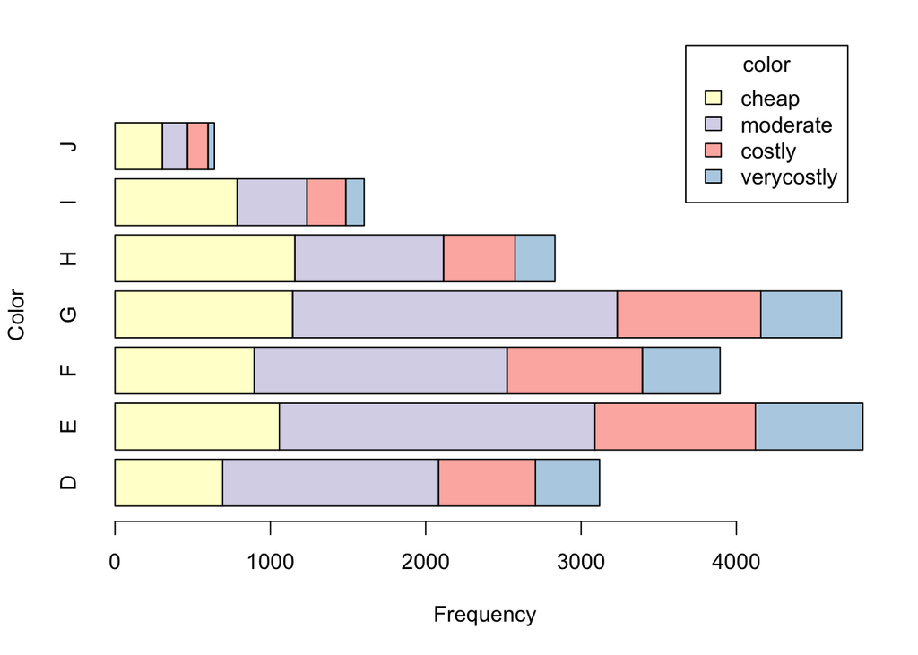

```r
# Create horizontal bar plot
barplot(table(dmd$Cprice, dmd$color),horiz = TRUE, col = palette("Set 3")[2:8] %>% alpha(0.6),
args.legend = list(x = "topright", inset = c(0.02,-0.15), title = "color"),legend.text = unique(dmd$Cprice), xlab = "Frequency", ylab = "Color")
```

In terms of which setup is better, it depends on the research question and the specific variables being analyzed. In this case, the original setup with ‘color’ as the rows and ‘Cprice’ as the columns provides more intuitive information about the distribution of diamond prices across different color categories.

### 9. Please check out the meaning of the categorical variable ‘carat’ and use the tapply()’ function to calculate the subsample averages of the ‘carat’ variable based on the cross-table in question 7.

```r
# Calculate subsample averages of carat variable based on cross-table
tapply(dmd$carat, list(dmd$color, dmd$Cprice), mean)
```

```
##       cheap  moderate    costly verycostly
## D 0.3090620 0.3458201 0.4137079  0.5120581
## E 0.2930151 0.3478877 0.4253727  0.5144220
## F 0.2972210 0.3524201 0.4428358  0.5236400
## G 0.3117832 0.3518191 0.4389177  0.5292678
## H 0.3125216 0.3571473 0.4827174  0.5450195
## I 0.3217154 0.3935189 0.5115600  0.5833051
## J 0.3425902 0.4411111 0.5527273  0.6770732
```

The ‘carat’ variable refers to the weight of the diamond in carats. A carat is a unit of weight used for measuring gemstones and pearls, with one carat equal to 200 milligrams.

The carat weight of a diamond is one of the main factors that determines its value,larger diamonds are more valuable than smaller ones.

This results in a table that shows the average carat values for each combination of ‘color’ and ‘Cprice’. The rows correspond to the color categories and the columns correspond to the price categories.

### 10. Please make a horizontal bar plot for the result of the previous question. Please set the following options ‘col = palette(“Set 3”)[2:8] %>% alpha(0.6)’, ‘main = “Subsample Averages of Carat”’, ‘args.legend = list(x = “topright”,horiz = T, title = “color”, inset = c(0.02,-0.05))’. Please check what these options do.

[figure not shown]

```r
# Calculate subsample averages of carat variable based on cross-table
avg_carat <- tapply(dmd$carat, list(dmd$color, dmd$Cprice), mean)

# Create horizontal bar plot
barplot(avg_carat, horiz = TRUE,
        col = palette("Set 3")[2:8] %>% alpha(0.6),legend.text = unique(dmd$color), args.legend = list(x = "topright", horiz = TRUE,
                           title = "color", inset = c(0.02,-0.05)),
        main = "Subsample Averages of Carat",
        )
```

The ‘col’ option sets the colors of the bars, using a color palette called “Set 3” from the ‘RColorBrewer’ package. The ‘%>%’ operator is used to pipe the color values through the ‘alpha()’ function to adjust their transparency.

The ‘main’ option sets the title of the plot.

The ‘args.legend’ option is a list that specifies the properties of the legend. In this case, we set the legend to appear in the top-right corner of the plot, with a horizontal orientation and a title of “color”. The ‘inset’ parameter adjusts the position of the legend relative to the plot.

### 11. Please add the following two commandsafter the ‘tapply()’ function, each with the %>% operator. Please speculate what these commands do.You can also embed plots, for example:

```r
tapply(dmd$carat, list(dmd$color, dmd$Cprice), mean) %>%
  .[order(.[,1],decreasing = T),] %>%
  .[,order(.[1,],decreasing = T)]
```

```
##   verycostly    costly  moderate     cheap
## J  0.6770732 0.5527273 0.4411111 0.3425902
## I  0.5833051 0.5115600 0.3935189 0.3217154
## H  0.5450195 0.4827174 0.3571473 0.3125216
## G  0.5292678 0.4389177 0.3518191 0.3117832
## D  0.5120581 0.4137079 0.3458201 0.3090620
## F  0.5236400 0.4428358 0.3524201 0.2972210
## E  0.5144220 0.4253727 0.3478877 0.2930151
```

### 12. please define an R function called ‘callprice’ for the above ‘C’ formula (Black-Scholes call option price) with 7 arguments ‘xt’ (the underlying asset price), ‘K’ (strike price), ‘t’ (the time period), ‘T’ (maturity), ‘R’ (interest rate), ‘eta’ (dividend rate), ‘sigma’ (volatility), for which the default values are ‘xt=10’, ‘K=10’, ‘t=0’, ‘T=1’, ‘R=0.03’, ‘eta=0.02’, ‘sigma=0.4’, respectively.

```r
callprice <- function(xt = 10, K = 10, t = 0, T = 1, R = 0.03, eta = 0.02, sigma = 0.4) {

  d1 <- (log(xt/K) + (R - eta + 0.5*sigma^2)*(T-t)) / (sigma*sqrt(T-t))
  d2 <- d1 - sigma*sqrt(T-t)

  N1 <- pnorm(d1)
  N2 <- pnorm(d2)

  call_price <- xt*exp(-eta*(T-t))*N1 - K*exp(-R*(T-t))*N2

  return(call_price)

}
```

The function takes 7 arguments, with default values set for each argument. The arguments represent:

xt: the underlying asset price K: the strike price t: the time period T: the maturity R: the interest rate eta: the dividend rate sigma: the volatility

Inside the function, the Black-Scholes formula is used to calculate the call option price. The function returns the calculated call option price as the output.

### 13. Define the following helper function to reformulate your ‘callprice()’ function with only 2 arguments of which the main argument ‘x’ is defined to be the ‘sigma’ argument of ‘callprice()’ and ‘T’ is the same as the ‘T’ argument of ‘callprice()’.

```r
ct = function(x,T)
{
  callprice(sigma = x, T = T)
}
```

### Please use this ‘ct()’ function with the ‘curve()’ function to draw three curves showing the relationship between the call option price and the volatility ‘sigma’ with ‘T’ set to be 1 (black color), 0.5 (green color), and 10 (red color), respectively. Also please add the following options to the ‘curve()’ function: ‘from = 0, to = 4, n = 200’. So the commands are as follows:

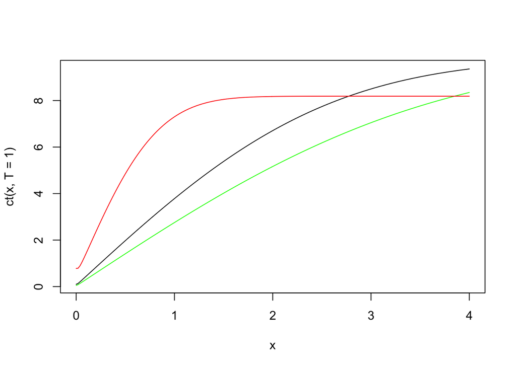

```r
curve(ct(x,T = 1), from = 0, to = 4, n = 200)
curve(ct(x,T = 0.5), from = 0, to = 4, n = 200, add = T, col = "green")
curve(ct(x,T = 10), from = 0, to = 4, n = 200, add = T, col = "red")
```

### Based on the resulting graph, explain how the two arguments ’sigma’ and ‘T’ of your ‘callprice()’ function affect the call option price. Can you explain why you need to define the helper function ‘ct()’.

We defined the helper function ct() to fix the value of the T argument in the callprice() function, so that we could use the resulting function with the curve() function to plot multiple curves with different values of T. This allowed us to easily visualize the effect of the T argument on the relationship between the call option price and volatility.

### 14. Please define another helper function to draw three curves showing the relationship between call option price and the underlying asset price ‘xt’ with ‘T’ set to be 1 (black color), 0.5 (green color), and 10 (red color), respectively. Also please add the following options to the ‘curve()’ function: ‘from = 0, to = 20, n = 200’

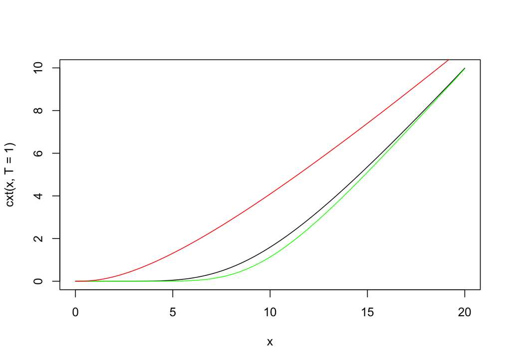

```r
#Another helper function
cxt = function(x,T)
{
  callprice(xt = x, T = T)
}

#plotting curve
curve(cxt(x,T = 1), from = 0, to = 20, n = 200)
curve(cxt(x,T = 0.5), from = 0, to = 20, n = 200, add = T, col = "green")
curve(cxt(x,T = 10), from = 0, to = 20, n = 200, add = T, col = "red")
```

From the plot, we can see that as the underlying asset price increases, the call option price also increases. We can also see that the effect of time on the call option price is more pronounced for long time periods (red line) than for shorter time periods (green line).